# Weyl's Law

Weyl's law determines the number of modes $N$ below a certain eigenvalue $\lambda$ for the Laplace operator. It determines also the asymptotic convergence of eigenvalues as modes order tends to infinity.

\begin{equation} N(\lambda) = \dfrac{A}{4\pi}\lambda \pm \dfrac{L}{4\pi}\sqrt{\lambda} + \dots, \end{equation}

which considers only the area $A$ and the perimeter $L$. The behavior of the eigenvalues can be expressed as

\begin{equation} \lambda = k^2=\dfrac{4\pi N}{A} \pm \dfrac{L}{A}\sqrt{\dfrac{4\pi N}{A}} + \dots \end{equation}

where $k$ is the acoustic wavenumber $k=\omega/ c$.

## Rectangular membrane

Consider a rectangular membrane, whose dimensions are $L_x=0.6$, $L_y=0.7$ with speed of sound $c=\sqrt{T/\rho_s}=1$, where $T$ is the tension value and $\rho_s$ the surface density. The sorted eigenvalues are

[interactive chart not shown]

## Irregular Shapes

For an irregular membrane shape, we compare also to an equivalent rectangular surface using a Green's based method. The predicted eigenvalues using the Green's method takes into account the maximum value of the static displacement an two characteristic lengths $l_x$ and $l_y$.

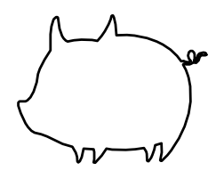

[interactive chart not shown]